# Attrition Project

Jiaqi Yang

2021/6/1

# I. Summary

### Background:

Employees are the key to a company. Employee attrition refers to a gradual but deliberate reduction in staff number due to employees retire or resign. Yet, it is not replaced, as an employer will not fill the vacancy left by the former employee. Frequently, from an organization perspective, a high employee attrition rate is not ideal, because it:

- wastes the cost in recruiting, assessing, hiring, and training the person
- makes the company lose the experienced employees
- lows workplace morale

By analyzing and predicting the attrition, the company can know why employees leave the company and identify potential actions to reduce employee attrition.

### Objectives

- Investigate the factors that drive employee attrition
- Predict employee attrition
- Discuss how to use the prediction results in practice

### Methodology

- Logistic regression
- Random forest

# II. Exploratory Data Analysis

**import data set & split training and testing data**

### 2.1 Loading the data set

```r
Employee_attrition_dataset <- read_csv("Employee attrition dataset.csv")
head(Employee_attrition_dataset)
```

```
## # A tibble: 6 x 11
##   attrition training_spend education_level job_title        gender_male
##   <lgl>              <dbl> <chr>           <chr>            <lgl>
## 1 FALSE               1942 MSc or MBA      Business analyst TRUE
## 2 FALSE               2032 BSc             Junior developer TRUE
## 3 TRUE                2115 MSc or MBA      Junior developer FALSE
## 4 FALSE               2028 MSc or MBA      Junior designer  FALSE
## 5 FALSE               1946 MSc or MBA      Associate        FALSE
## 6 TRUE                1743 BSc             Developer        TRUE
## # ... with 6 more variables: performance_rating <dbl>, boss_rating_avg <dbl>,
## #   salary <dbl>, overtime_per_week <dbl>, traveldays_per_year <dbl>,
## #   lastpromotion_months <dbl>
```

### 2.2 Check for missing data

```r
sum(is.na(Employee_attrition_dataset))
```

```
## [1] 0
```

### 2.3 Data split to training and testing

I took 80% for the training part.

```r
set.seed(31)
indeces <- sample(nrow(Employee_attrition_dataset),nrow(Employee_attrition_dataset)*0.8)

train <- Employee_attrition_dataset[indeces,]
test <- Employee_attrition_dataset[-indeces,]
```

## 2.4 Overview

```r
summary(train)
```

```
##  attrition       training_spend education_level     job_title
##  Mode :logical   Min.   :1238   Length:1720        Length:1720
##  FALSE:1389      1st Qu.:1848   Class :character   Class :character
##  TRUE :331       Median :2008   Mode  :character   Mode  :character
##                  Mean   :2008
##                  3rd Qu.:2171
##                  Max.   :2823
##  gender_male     performance_rating boss_rating_avg     salary
##  Mode :logical   Min.   :1.000      Min.   :1.00    Min.   : 3584
##  FALSE:720       1st Qu.:2.000      1st Qu.:2.30    1st Qu.: 4022
##  TRUE :1000      Median :3.000      Median :3.00    Median : 4419
##                  Mean   :2.974      Mean   :2.96    Mean   : 4980
##                  3rd Qu.:4.000      3rd Qu.:3.60    3rd Qu.: 5606
##                  Max.   :5.000      Max.   :5.00    Max.   :10553
##  overtime_per_week traveldays_per_year lastpromotion_months
##  Min.   : 0.000    Min.   : 0.0        Min.   : 0.00
##  1st Qu.: 2.000    1st Qu.:14.0        1st Qu.:12.00
##  Median : 4.000    Median :20.0        Median :18.00
##  Mean   : 4.872    Mean   :20.6        Mean   :18.59
##  3rd Qu.: 7.000    3rd Qu.:27.0        3rd Qu.:25.00
##  Max.   :16.000    Max.   :53.0        Max.   :51.00
```

```r
summary(test)
```

```
##  attrition       training_spend education_level     job_title
##  Mode :logical   Min.   :1298   Length:430         Length:430
##  FALSE:351       1st Qu.:1806   Class :character   Class :character
##  TRUE :79        Median :1986   Mode  :character   Mode  :character
##                  Mean   :1989
##                  3rd Qu.:2171
##                  Max.   :2848
##  gender_male     performance_rating boss_rating_avg     salary
##  Mode :logical   Min.   :1.000      Min.   :1.000   Min.   : 3605
##  FALSE:215       1st Qu.:2.000      1st Qu.:2.400   1st Qu.: 4016
##  TRUE :215       Median :3.000      Median :2.900   Median : 4397
##                  Mean   :3.033      Mean   :2.988   Mean   : 4950
##                  3rd Qu.:4.000      3rd Qu.:3.600   3rd Qu.: 5694
##                  Max.   :5.000      Max.   :5.000   Max.   :10604
##  overtime_per_week traveldays_per_year lastpromotion_months
##  Min.   : 0.000    Min.   : 0.00       Min.   : 0.00
##  1st Qu.: 2.000    1st Qu.:14.00       1st Qu.:11.00
##  Median : 4.000    Median :20.00       Median :18.00
##  Mean   : 4.949    Mean   :20.95       Mean   :18.03
##  3rd Qu.: 7.000    3rd Qu.:27.00       3rd Qu.:24.00
##  Max.   :17.000    Max.   :48.00       Max.   :43.00
```

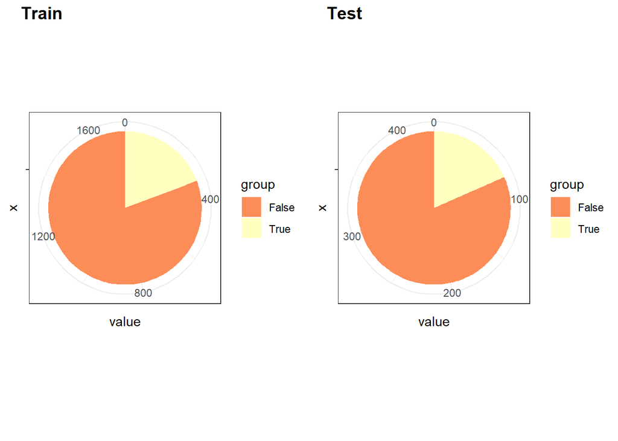

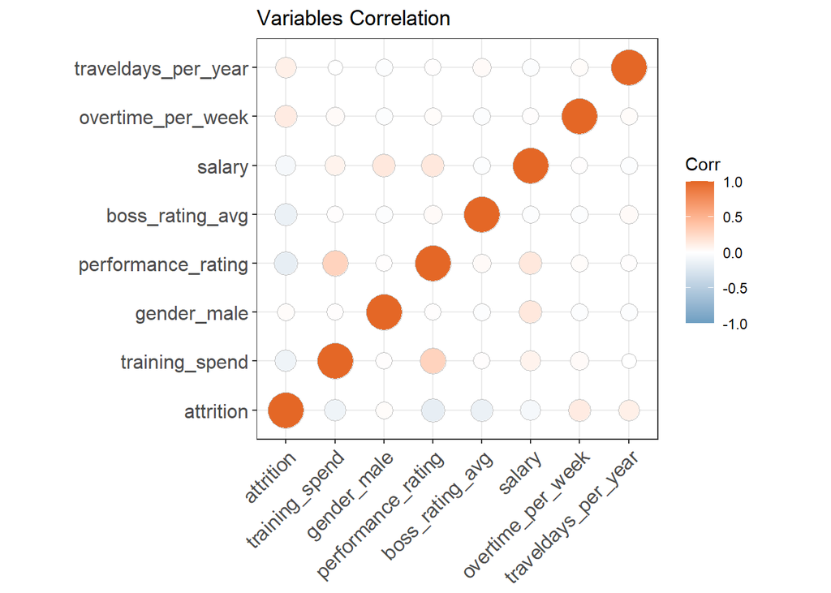

It can be concluded that attrition positively correlates with overtime, but negatively with performance, training spends and boss rating.

# III. Logistic regression

### 3.1 Build the model

As there are categorical dependent variables, I build a logistic regression using the training data set.

```r
fit_logistic <- glm(attrition ~., family=binomial(logit),
                    data = train, maxit=1000)
summary(fit_logistic)
```

```
##
## Call:
## glm(formula = attrition ~ ., family = binomial(logit), data = train,
##     maxit = 1000)
##
## Deviance Residuals:
##     Min       1Q   Median       3Q      Max
## -1.6475  -0.6677  -0.4586  -0.2398   2.8757
##
## Coefficients:
##                                 Estimate Std. Error z value Pr(>|z|)
## (Intercept)                    1.7363956  4.1665396   0.417 0.676863
## training_spend                -0.0009460  0.0002869  -3.297 0.000977 ***
## education_levelDSc or PhD     -1.2207098  0.6281453  -1.943 0.051973 .
## education_levelMSc or MBA      0.3069033  0.1371203   2.238 0.025208 *
## job_titleBusiness analyst     -0.6143517  1.0845703  -0.566 0.571090
## job_titleConsultant           -0.0408480  2.1008135  -0.019 0.984487
## job_titleDesigner              0.5663419  0.6106653   0.927 0.353710
## job_titleDeveloper             0.9054075  0.5709740   1.586 0.112802
## job_titleJunior designer       0.2409908  1.0802660   0.223 0.823470
## job_titleJunior developer      0.2499053  1.0728769   0.233 0.815816
## job_titleLead designer         1.3786008  3.1163951   0.442 0.658221
## job_titleLead developer        1.9056669  3.6959823   0.516 0.606130
## job_titlePrincipal consultant  0.8309494  4.1186944   0.202 0.840112
## job_titleSenior designer       0.7088010  1.5935180   0.445 0.656462
## job_titleSenior developer      0.3144047  1.6044196   0.196 0.844640
## gender_maleTRUE                0.1510139  0.1369206   1.103 0.270057
## performance_rating            -0.3947727  0.2054264  -1.922 0.054641 .
## boss_rating_avg               -0.4717009  0.0766940  -6.150 7.73e-10 ***
## salary                        -0.0003101  0.0009056  -0.342 0.732017
## overtime_per_week              0.1107597  0.0194138   5.705 1.16e-08 ***
## traveldays_per_year            0.0335763  0.0069784   4.811 1.50e-06 ***
## lastpromotion_months           0.0451119  0.0070345   6.413 1.43e-10 ***
## ---
## Signif. codes:  0 '***' 0.001 '**' 0.01 '*' 0.05 '.' 0.1 ' ' 1
##
## (Dispersion parameter for binomial family taken to be 1)
##
##     Null deviance: 1684.7  on 1719  degrees of freedom
## Residual deviance: 1443.6  on 1698  degrees of freedom
## AIC: 1487.6
##
## Number of Fisher Scoring iterations: 5
```

```r
fit_logistic1 <- glm(attrition ~.-job_title - gender_male - salary, family=binomial(logit),
                     data = train, maxit=1000)
summary(fit_logistic1)
```

```
##
## Call:
## glm(formula = attrition ~ . - job_title - gender_male - salary,
##     family = binomial(logit), data = train, maxit = 1000)
##
## Deviance Residuals:
##     Min       1Q   Median       3Q      Max
## -1.7729  -0.6699  -0.4719  -0.2862   2.7673
##
## Coefficients:
##                             Estimate Std. Error z value Pr(>|z|)
## (Intercept)                0.7685402  0.6119961   1.256   0.2092
## training_spend            -0.0009152  0.0002826  -3.238   0.0012 **
## education_levelDSc or PhD -1.4602489  0.6198791  -2.356   0.0185 *
## education_levelMSc or MBA  0.2752029  0.1331694   2.067   0.0388 *
## performance_rating        -0.4489357  0.0726646  -6.178 6.48e-10 ***
## boss_rating_avg           -0.4553532  0.0749237  -6.078 1.22e-09 ***
## overtime_per_week          0.1051181  0.0190804   5.509 3.60e-08 ***
## traveldays_per_year        0.0318625  0.0068609   4.644 3.42e-06 ***
## lastpromotion_months       0.0448719  0.0069394   6.466 1.00e-10 ***
## ---
## Signif. codes:  0 '***' 0.001 '**' 0.01 '*' 0.05 '.' 0.1 ' ' 1
##
## (Dispersion parameter for binomial family taken to be 1)
##
##     Null deviance: 1684.7  on 1719  degrees of freedom
## Residual deviance: 1482.2  on 1711  degrees of freedom
## AIC: 1500.2
##
## Number of Fisher Scoring iterations: 5
```

```r
sig_coeff <- fit_logistic$coefficients[ summary(fit_logistic)$coefficients[,4] < .05]
sig_coeff
```

```
##            training_spend education_levelMSc or MBA           boss_rating_avg
##             -0.0009460341              0.3069032934             -0.4717009010
##         overtime_per_week       traveldays_per_year      lastpromotion_months
##              0.1107597443              0.0335762737              0.0451119081
```

```r
sig_coeff <- data.frame(b=round(sig_coeff,2), exp_b=round(exp(sig_coeff),2)); sig_coeff
```

```
##                               b exp_b
## training_spend             0.00  1.00
## education_levelMSc or MBA  0.31  1.36
## boss_rating_avg           -0.47  0.62
## overtime_per_week          0.11  1.12
## traveldays_per_year        0.03  1.03
## lastpromotion_months       0.05  1.05
```

```r
tr_d <- train
te_d <- test

tr_d$seniority <- tr_d$job_title == "Lead designer" | tr_d$job_title == "Lead developer" | tr_d$job_title == "Principal consultant" | tr_d$job_title == "Senior designer" | tr_d$job_title == "Senior developer"
te_d$seniority <- te_d$job_title == "Lead designer" | te_d$job_title == "Lead developer" | te_d$job_title == "Principal consultant" | te_d$job_title == "Senior designer" | te_d$job_title == "Senior developer"
tr_d <- tr_d[,-4]
te_d <- te_d[,-4]
#View(tr_d)

tr_d$performance_rating <- as.factor(tr_d$performance_rating)
te_d$performance_rating <- as.factor(te_d$performance_rating)

# View(tr_d)

fit_logistic2 <- glm(attrition ~ . - gender_male - salary, family = binomial(logit), data= tr_d, maxit=1000)
summary(fit_logistic2)
```

```
##
## Call:
## glm(formula = attrition ~ . - gender_male - salary, family = binomial(logit),
##     data = tr_d, maxit = 1000)
##
## Deviance Residuals:
##     Min       1Q   Median       3Q      Max
## -1.6753  -0.6531  -0.4628  -0.2741   2.8666
##
## Coefficients:
##                             Estimate Std. Error z value Pr(>|z|)
## (Intercept)               -0.0500134  0.6536436  -0.077 0.939010
## training_spend            -0.0008880  0.0002873  -3.091 0.001996 **
## education_levelDSc or PhD -1.3827133  0.6309016  -2.192 0.028405 *
## education_levelMSc or MBA  0.3076610  0.1346849   2.284 0.022354 *
## performance_rating2        0.1376297  0.2539337   0.542 0.587825
## performance_rating3       -0.8798427  0.2570370  -3.423 0.000619 ***
## performance_rating4       -0.9612392  0.2788986  -3.447 0.000568 ***
## performance_rating5       -1.0794130  0.4358564  -2.477 0.013267 *
## boss_rating_avg           -0.4597916  0.0754928  -6.091 1.13e-09 ***
## overtime_per_week          0.1097142  0.0193163   5.680 1.35e-08 ***
## traveldays_per_year        0.0316794  0.0068950   4.595 4.34e-06 ***
## lastpromotion_months       0.0463948  0.0070009   6.627 3.43e-11 ***
## seniorityTRUE             -0.3345441  0.2373598  -1.409 0.158705
## ---
## Signif. codes:  0 '***' 0.001 '**' 0.01 '*' 0.05 '.' 0.1 ' ' 1
##
## (Dispersion parameter for binomial family taken to be 1)
##
##     Null deviance: 1684.7  on 1719  degrees of freedom
## Residual deviance: 1463.7  on 1707  degrees of freedom
## AIC: 1489.7
##
## Number of Fisher Scoring iterations: 5
```

```r
fit_logistic3 <- glm(attrition ~ . - gender_male - salary - seniority, family = binomial(logit), data= tr_d, maxit=1000)
summary(fit_logistic3)
```

```
##
## Call:
## glm(formula = attrition ~ . - gender_male - salary - seniority,
##     family = binomial(logit), data = tr_d, maxit = 1000)
##
## Deviance Residuals:
##     Min       1Q   Median       3Q      Max
## -1.6491  -0.6528  -0.4650  -0.2785   2.7862
##
## Coefficients:
##                             Estimate Std. Error z value Pr(>|z|)
## (Intercept)               -0.0699609  0.6523476  -0.107 0.914595
## training_spend            -0.0009015  0.0002864  -3.148 0.001646 **
## education_levelDSc or PhD -1.4599942  0.6265594  -2.330 0.019797 *
## education_levelMSc or MBA  0.2933671  0.1342212   2.186 0.028838 *
## performance_rating2        0.1563841  0.2529669   0.618 0.536444
## performance_rating3       -0.8604189  0.2558623  -3.363 0.000772 ***
## performance_rating4       -0.9460150  0.2777946  -3.405 0.000661 ***
## performance_rating5       -1.0604603  0.4353360  -2.436 0.014852 *
## boss_rating_avg           -0.4580061  0.0752385  -6.087 1.15e-09 ***
## overtime_per_week          0.1091202  0.0192919   5.656 1.55e-08 ***
## traveldays_per_year        0.0318866  0.0068934   4.626 3.73e-06 ***
## lastpromotion_months       0.0463641  0.0069990   6.624 3.49e-11 ***
## ---
## Signif. codes:  0 '***' 0.001 '**' 0.01 '*' 0.05 '.' 0.1 ' ' 1
##
## (Dispersion parameter for binomial family taken to be 1)
##
##     Null deviance: 1684.7  on 1719  degrees of freedom
## Residual deviance: 1465.8  on 1708  degrees of freedom
## AIC: 1489.8
##
## Number of Fisher Scoring iterations: 5
```

# IV. Random Forest

## 4.1 Build the model

```r
model_forest1 <- randomForest(attrition ~ ., data=train,
                              method="class", ntree=500)
model_forest2 <- randomForest(attrition~.-job_title - gender_male - salary, data=train, method="class", ntree=500)
```

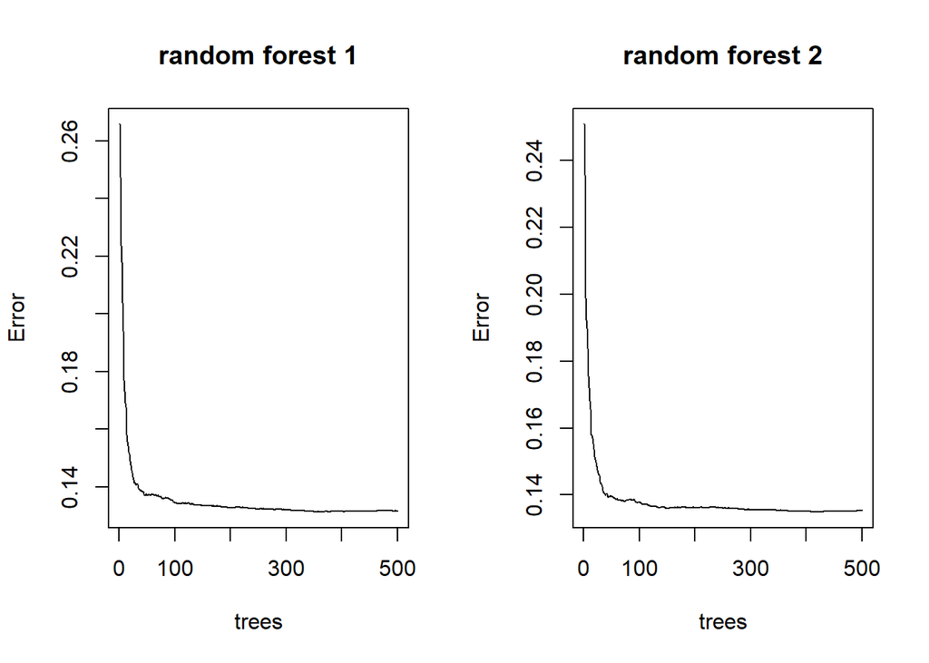

```r
par(mfrow=c(1,2))
plot(model_forest1, main="random forest 1")
plot(model_forest2, main="random forest 2")
```

# V. Predict the result

```r
# Check the prediction for the 3rd model
predictions_logistic_3 <-  predict(fit_logistic3, newdata = te_d, type = 'response')

#head(round(predictions_logistic,4))
#head(te_d$attrition)

#confusion matrix
conf_matrix <- confusionMatrix(as.factor(te_d$attrition==1),
                                data=as.factor(predictions_logistic_3 > 0.5), positive="TRUE")
ctable3 <-  conf_matrix$table


#comparing with other models

# no kick out
predictions_logistic_0 <-  predict(fit_logistic, newdata = test, type = 'response')

conf_matrix_0 <- confusionMatrix(as.factor(test$attrition==1),
                                data=as.factor(predictions_logistic_0 > 0.5), positive="TRUE")
ctable0 <-  conf_matrix_0$table

# kick out everything
predictions_logistic_1<-  predict(fit_logistic1, newdata = test, type = 'response')
conf_matrix_1 <- confusionMatrix(as.factor(test$attrition==1),
                                  data=as.factor(predictions_logistic_1>0.5), positive='TRUE')
ctable1 <-  conf_matrix_1$table
# 2
predictions_logistic_2<-  predict(fit_logistic2, newdata = te_d, type = 'response')
conf_matrix_2 <- confusionMatrix(as.factor(te_d$attrition==1),
                                  data=as.factor(predictions_logistic_2>0.5), positive='TRUE')
ctable2 <-  conf_matrix_2$table


prediction_forest1 <- predict(model_forest1, newdata = test, type = 'class')
conf_matrix_21 <- confusionMatrix(as.factor(test$attrition==1),
                                  data=as.factor(prediction_forest1 >0.5), positive='TRUE')
ctable21 <-  conf_matrix_21$table

#conf_matrix_21

prediction_forest2 <- predict(model_forest2, newdata = test, type = 'class')
conf_matrix_22 <- confusionMatrix(as.factor(test$attrition==1),
                                  data=as.factor(prediction_forest2 >0.5), positive='TRUE')
#conf_matrix_22
ctable22 <-  conf_matrix_22$table
```

# VI. Analyze the predictions

[figure not shown]

```
##    condition        type  value
## 1      log_0    accuracy 0.8093
## 2      log_l    accuracy 0.8140
## 3      log_2    accuracy 0.8163
## 4      log_3    accuracy 0.8140
## 5   forest_1    accuracy 0.8209
## 6   forest_2    accuracy 0.8279
## 7      log_0 sensitivity 0.1300
## 8      log_l sensitivity 0.0900
## 9      log_2 sensitivity 0.1400
## 10     log_3 sensitivity 0.1400
## 11  forest_1 sensitivity 0.2200
## 12  forest_2 sensitivity 0.2700
## 13     log_0 specificity 0.9600
## 14     log_l specificity 0.9800
## 15     log_2 specificity 0.9700
## 16     log_3 specificity 0.9700
## 17  forest_1 specificity 0.9600
## 18  forest_2 specificity 0.9500
```

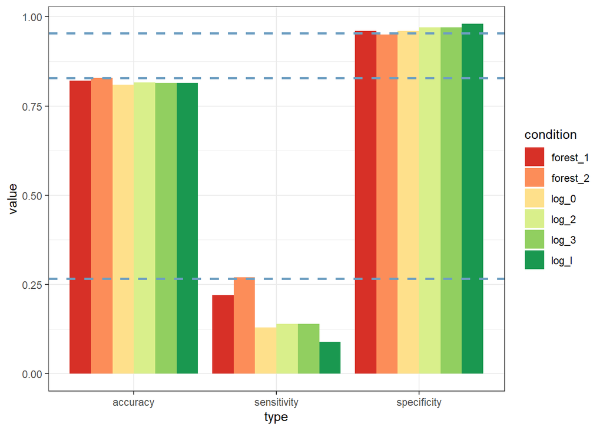

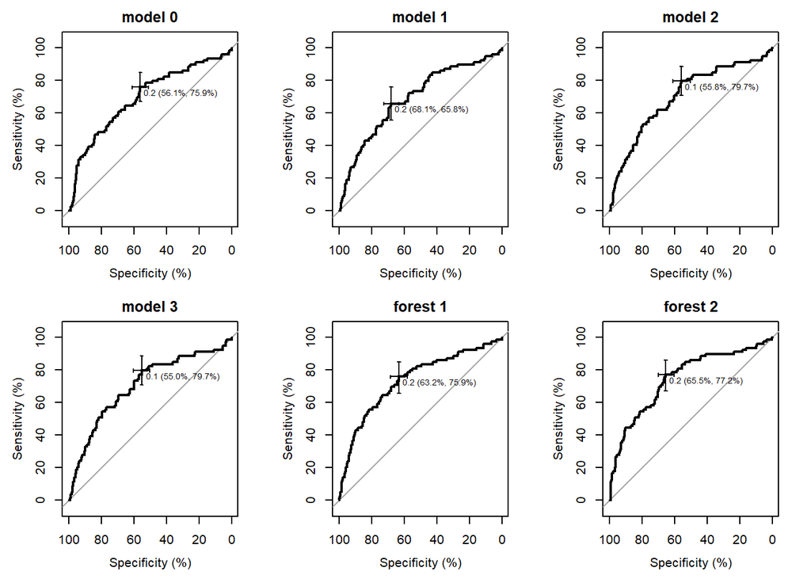

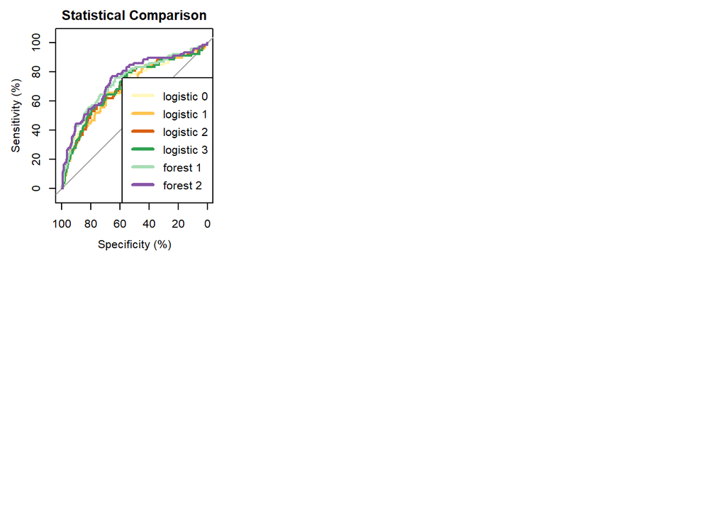

# VII. Conclusion:

The second random forest model gives the best prediction. Yet, the company needs to evaluate between type I error and type II error, and consider which type of error is the most unacceptable. The model shows that $job_title$,$gender$,$salary$ are not essentially relevant to employee attrition. In other words, those factors cannot make an employee stay in the company. The model and results are useful for the top management team and HR.

1. HR: - can prepare actions to retain the employees. For example, HR may arrange a face-to-face conversation to identify the reasons. So if it turns out that they think the traveling days are overwhelming, HR can inform the supervisor and suggest reorganizing the working schedule slightly.
   - can prepare for the next round of recruitment. If the company can find someone else to replace the position, the attrition will become normal employee turnover.
2. top management team: - As the results show that both $training_spend$ and $boss_rating_avg$ are one of the factors to attrition, the top management can balance the overall company profits and decide the increase the employee spend in the next year.
   - Besides, the top management team can have another project to identify how to improve the boss rating.
   - Since employees prefer to stay in a company without an obvious hierarchy, the top manager can evaluate and improve the company culture to become more transparent and agile.